# Risk Factor Analysis

## Outcome Variable

**Outcome Variable:** haz

## Predictor Variables

**Intervention Variable:** exclfeed36

**Adjustment Set:**

unadjusted

## Stratifying Variables

The analysis was stratified on these variable(s):

- agecat
- studyid
- country

## Data Summary

| agecat | studyid | country | exclfeed36 | n_cell | n |
| --- | --- | --- | --- | --- | --- |
| Birth | ki0047075b-MAL-ED | BANGLADESH | 1 | 62 | 243 |
| Birth | ki0047075b-MAL-ED | BANGLADESH | 0 | 181 | 243 |
| Birth | ki0047075b-MAL-ED | BRAZIL | 1 | 13 | 185 |
| Birth | ki0047075b-MAL-ED | BRAZIL | 0 | 172 | 185 |
| Birth | ki0047075b-MAL-ED | INDIA | 1 | 5 | 198 |
| Birth | ki0047075b-MAL-ED | INDIA | 0 | 193 | 198 |
| Birth | ki0047075b-MAL-ED | NEPAL | 1 | 11 | 172 |
| Birth | ki0047075b-MAL-ED | NEPAL | 0 | 161 | 172 |
| Birth | ki0047075b-MAL-ED | PERU | 1 | 15 | 273 |
| Birth | ki0047075b-MAL-ED | PERU | 0 | 258 | 273 |
| Birth | ki0047075b-MAL-ED | SOUTH AFRICA | 1 | 0 | 236 |
| Birth | ki0047075b-MAL-ED | SOUTH AFRICA | 0 | 236 | 236 |
| Birth | ki0047075b-MAL-ED | TANZANIA, UNITED REPUBLIC OF | 1 | 1 | 121 |
| Birth | ki0047075b-MAL-ED | TANZANIA, UNITED REPUBLIC OF | 0 | 120 | 121 |
| Birth | ki1000108-CMC-V-BCS-2002 | INDIA | 1 | 3 | 3 |
| Birth | ki1000108-CMC-V-BCS-2002 | INDIA | 0 | 0 | 3 |
| Birth | ki1000108-IRC | INDIA | 1 | 0 | 4 |
| Birth | ki1000108-IRC | INDIA | 0 | 4 | 4 |
| Birth | ki1000109-EE | PAKISTAN | 1 | 1 | 2 |
| Birth | ki1000109-EE | PAKISTAN | 0 | 1 | 2 |
| Birth | ki1101329-Keneba | GAMBIA | 1 | 363 | 1252 |
| Birth | ki1101329-Keneba | GAMBIA | 0 | 889 | 1252 |
| Birth | kiGH5241-JiVitA-3 | BANGLADESH | 1 | 11155 | 13946 |
| Birth | kiGH5241-JiVitA-3 | BANGLADESH | 0 | 2791 | 13946 |
| Birth | kiGH5241-JiVitA-4 | BANGLADESH | 1 | 580 | 727 |
| Birth | kiGH5241-JiVitA-4 | BANGLADESH | 0 | 147 | 727 |
| 6 months | ki0047075b-MAL-ED | BANGLADESH | 1 | 63 | 240 |
| 6 months | ki0047075b-MAL-ED | BANGLADESH | 0 | 177 | 240 |
| 6 months | ki0047075b-MAL-ED | BRAZIL | 1 | 17 | 209 |
| 6 months | ki0047075b-MAL-ED | BRAZIL | 0 | 192 | 209 |

[output cut: 60 more lines]

The following strata were considered:

- agecat: 24 months, studyid: ki0047075b-MAL-ED, country: BANGLADESH
- agecat: 24 months, studyid: ki0047075b-MAL-ED, country: BRAZIL
- agecat: 24 months, studyid: ki0047075b-MAL-ED, country: INDIA
- agecat: 24 months, studyid: ki0047075b-MAL-ED, country: NEPAL
- agecat: 24 months, studyid: ki0047075b-MAL-ED, country: PERU
- agecat: 24 months, studyid: ki0047075b-MAL-ED, country: SOUTH AFRICA
- agecat: 24 months, studyid: ki0047075b-MAL-ED, country: TANZANIA, UNITED REPUBLIC OF
- agecat: 24 months, studyid: ki1000108-CMC-V-BCS-2002, country: INDIA
- agecat: 24 months, studyid: ki1000108-IRC, country: INDIA
- agecat: 24 months, studyid: ki1017093b-PROVIDE, country: BANGLADESH
- agecat: 24 months, studyid: ki1101329-Keneba, country: GAMBIA
- agecat: 24 months, studyid: ki1113344-GMS-Nepal, country: NEPAL
- agecat: 24 months, studyid: ki1148112-LCNI-5, country: MALAWI
- agecat: 24 months, studyid: kiGH5241-JiVitA-3, country: BANGLADESH
- agecat: 24 months, studyid: kiGH5241-JiVitA-4, country: BANGLADESH
- agecat: 6 months, studyid: ki0047075b-MAL-ED, country: BANGLADESH
- agecat: 6 months, studyid: ki0047075b-MAL-ED, country: BRAZIL
- agecat: 6 months, studyid: ki0047075b-MAL-ED, country: INDIA
- agecat: 6 months, studyid: ki0047075b-MAL-ED, country: NEPAL
- agecat: 6 months, studyid: ki0047075b-MAL-ED, country: PERU
- agecat: 6 months, studyid: ki0047075b-MAL-ED, country: SOUTH AFRICA
- agecat: 6 months, studyid: ki0047075b-MAL-ED, country: TANZANIA, UNITED REPUBLIC OF
- agecat: 6 months, studyid: ki1000108-CMC-V-BCS-2002, country: INDIA
- agecat: 6 months, studyid: ki1000108-IRC, country: INDIA
- agecat: 6 months, studyid: ki1000109-EE, country: PAKISTAN
- agecat: 6 months, studyid: ki1000304b-SAS-FoodSuppl, country: INDIA
- agecat: 6 months, studyid: ki1017093b-PROVIDE, country: BANGLADESH
- agecat: 6 months, studyid: ki1101329-Keneba, country: GAMBIA
- agecat: 6 months, studyid: ki1113344-GMS-Nepal, country: NEPAL
- agecat: 6 months, studyid: ki1148112-LCNI-5, country: MALAWI
- agecat: 6 months, studyid: kiGH5241-JiVitA-3, country: BANGLADESH
- agecat: 6 months, studyid: kiGH5241-JiVitA-4, country: BANGLADESH
- agecat: Birth, studyid: ki0047075b-MAL-ED, country: BANGLADESH
- agecat: Birth, studyid: ki0047075b-MAL-ED, country: BRAZIL
- agecat: Birth, studyid: ki0047075b-MAL-ED, country: INDIA
- agecat: Birth, studyid: ki0047075b-MAL-ED, country: NEPAL
- agecat: Birth, studyid: ki0047075b-MAL-ED, country: PERU
- agecat: Birth, studyid: ki0047075b-MAL-ED, country: SOUTH AFRICA
- agecat: Birth, studyid: ki0047075b-MAL-ED, country: TANZANIA, UNITED REPUBLIC OF
- agecat: Birth, studyid: ki1000108-CMC-V-BCS-2002, country: INDIA
- agecat: Birth, studyid: ki1000108-IRC, country: INDIA
- agecat: Birth, studyid: ki1000109-EE, country: PAKISTAN
- agecat: Birth, studyid: ki1101329-Keneba, country: GAMBIA
- agecat: Birth, studyid: kiGH5241-JiVitA-3, country: BANGLADESH
- agecat: Birth, studyid: kiGH5241-JiVitA-4, country: BANGLADESH

### Dropped Strata

Some strata were dropped due to rare outcomes:

- agecat: Birth, studyid: ki0047075b-MAL-ED, country: SOUTH AFRICA
- agecat: Birth, studyid: ki0047075b-MAL-ED, country: TANZANIA, UNITED REPUBLIC OF
- agecat: Birth, studyid: ki1000108-CMC-V-BCS-2002, country: INDIA
- agecat: Birth, studyid: ki1000108-IRC, country: INDIA
- agecat: Birth, studyid: ki1000109-EE, country: PAKISTAN
- agecat: 6 months, studyid: ki0047075b-MAL-ED, country: SOUTH AFRICA
- agecat: 6 months, studyid: ki0047075b-MAL-ED, country: TANZANIA, UNITED REPUBLIC OF
- agecat: 6 months, studyid: ki1000108-CMC-V-BCS-2002, country: INDIA
- agecat: 6 months, studyid: ki1000108-IRC, country: INDIA
- agecat: 6 months, studyid: ki1000304b-SAS-FoodSuppl, country: INDIA
- agecat: 24 months, studyid: ki0047075b-MAL-ED, country: SOUTH AFRICA
- agecat: 24 months, studyid: ki0047075b-MAL-ED, country: TANZANIA, UNITED REPUBLIC OF
- agecat: 24 months, studyid: ki1000108-CMC-V-BCS-2002, country: INDIA
- agecat: 24 months, studyid: ki1000108-IRC, country: INDIA

## Methods Detail

We’re interested in the causal parameters $E[Y_a]$ for all values of $a \in \mathcal{A}$. These parameters represent the mean outcome if, possibly contrary to fact, we intervened to set all units to have $A=a$. Under the randomization and positivity assumptions, these are identified by the statistical parameters $\psi_a=E_W[E_{Y|A,W}(Y|A=a,W)]$. In addition, we’re interested in the mean of $Y$, $E[Y]$ under no intervention (the observed mean). We will estimate these parameters by using SuperLearner to fit the relevant likelihood factors – $E_{Y|A,W}(Y|A=a,W)$ and $p(A=a|W)$, and then updating our likelihood fit using a joint TMLE.

For unadjusted analyses ($W=\{\}$), initial likelihoods were estimated using Lrnr_glm to estimate the simple $E(Y|A)$ and Lrnr_mean to estimate $p(A)$. For adjusted analyses, a small library containing Lrnr_glmnet, Lrnr_xgboost, and Lrnr_mean was used.

Having estimated these parameters, we will then use the delta method to estimate relative risks and attributable risks relative to a prespecified baseline level of $A$.

# Results Detail

## Results Plots

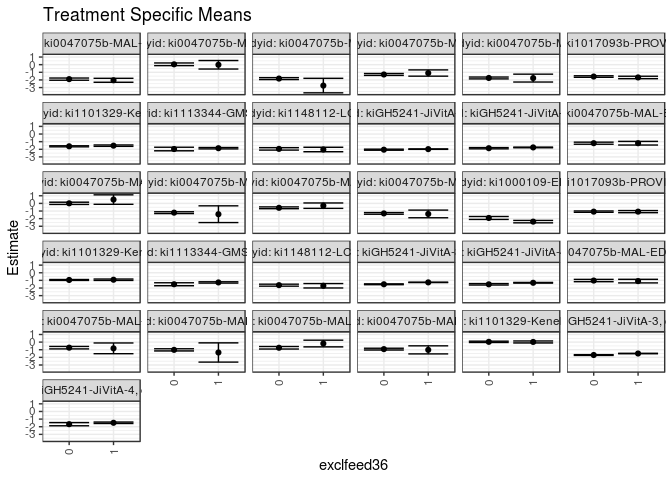

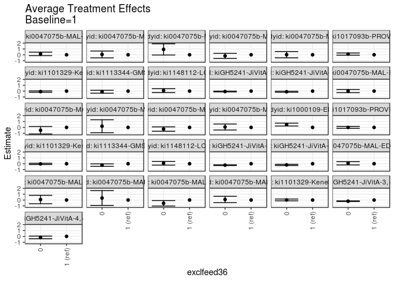

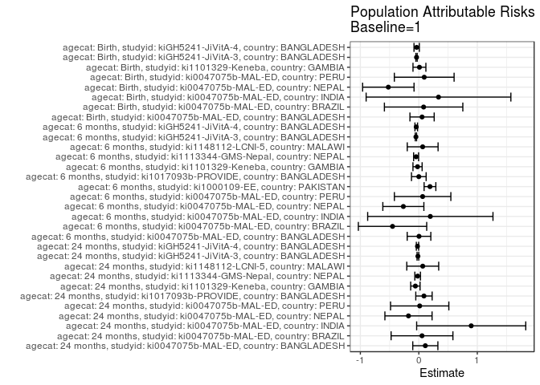

## Results Table

### Parameter: TSM

| agecat | studyid | country | intervention_level | baseline_level | estimate | ci_lower | ci_upper |
| --- | --- | --- | --- | --- | --- | --- | --- |
| Birth | ki0047075b-MAL-ED | BANGLADESH | 1 | NA | -1.0967742 | -1.3305880 | -0.8629603 |
| Birth | ki0047075b-MAL-ED | BANGLADESH | 0 | NA | -1.0225414 | -1.1733683 | -0.8717146 |
| Birth | ki0047075b-MAL-ED | BRAZIL | 1 | NA | -0.8169231 | -1.5196519 | -0.1141943 |
| Birth | ki0047075b-MAL-ED | BRAZIL | 0 | NA | -0.7288953 | -0.8917434 | -0.5660473 |
| Birth | ki0047075b-MAL-ED | INDIA | 1 | NA | -1.3600000 | -2.6217741 | -0.0982259 |
| Birth | ki0047075b-MAL-ED | INDIA | 0 | NA | -1.0148187 | -1.1567569 | -0.8728804 |
| Birth | ki0047075b-MAL-ED | NEPAL | 1 | NA | -0.1836364 | -0.6233463 | 0.2560736 |
| Birth | ki0047075b-MAL-ED | NEPAL | 0 | NA | -0.7409317 | -0.9049964 | -0.5768669 |
| Birth | ki0047075b-MAL-ED | PERU | 1 | NA | -1.0153333 | -1.5437063 | -0.4869604 |
| Birth | ki0047075b-MAL-ED | PERU | 0 | NA | -0.9177519 | -1.0326558 | -0.8028481 |
| Birth | ki1101329-Keneba | GAMBIA | 1 | NA | 0.0221763 | -0.1080686 | 0.1524212 |
| Birth | ki1101329-Keneba | GAMBIA | 0 | NA | 0.0368504 | -0.0478641 | 0.1215649 |
| Birth | kiGH5241-JiVitA-3 | BANGLADESH | 1 | NA | -1.4940394 | -1.5179013 | -1.4701776 |
| Birth | kiGH5241-JiVitA-3 | BANGLADESH | 0 | NA | -1.6905554 | -1.7412317 | -1.6398790 |
| Birth | kiGH5241-JiVitA-4 | BANGLADESH | 1 | NA | -1.4830862 | -1.5770285 | -1.3891440 |
| Birth | kiGH5241-JiVitA-4 | BANGLADESH | 0 | NA | -1.6659864 | -1.8724599 | -1.4595129 |
| 6 months | ki0047075b-MAL-ED | BANGLADESH | 1 | NA | -1.2036772 | -1.4422396 | -0.9651149 |
| 6 months | ki0047075b-MAL-ED | BANGLADESH | 0 | NA | -1.1996139 | -1.3345054 | -1.0647225 |
| 6 months | ki0047075b-MAL-ED | BRAZIL | 1 | NA | 0.5008824 | -0.1181711 | 1.1199358 |
| 6 months | ki0047075b-MAL-ED | BRAZIL | 0 | NA | 0.0111892 | -0.1343709 | 0.1567494 |
| 6 months | ki0047075b-MAL-ED | INDIA | 1 | NA | -1.4169048 | -2.5149859 | -0.3188236 |
| 6 months | ki0047075b-MAL-ED | INDIA | 0 | NA | -1.2143595 | -1.3315781 | -1.0971410 |
| 6 months | ki0047075b-MAL-ED | NEPAL | 1 | NA | -0.2963333 | -0.6521240 | 0.0594573 |
| 6 months | ki0047075b-MAL-ED | NEPAL | 0 | NA | -0.5790271 | -0.6965873 | -0.4614670 |
| 6 months | ki0047075b-MAL-ED | PERU | 1 | NA | -1.3821875 | -1.8834381 | -0.8809369 |
| 6 months | ki0047075b-MAL-ED | PERU | 0 | NA | -1.3133007 | -1.4233461 | -1.2032552 |
| 6 months | ki1000109-EE | PAKISTAN | 1 | NA | -2.3915090 | -2.5470464 | -2.2359716 |
| 6 months | ki1000109-EE | PAKISTAN | 0 | NA | -1.9091724 | -2.1006572 | -1.7176877 |
| 6 months | ki1017093b-PROVIDE | BANGLADESH | 1 | NA | -1.0804286 | -1.2192597 | -0.9415974 |
| 6 months | ki1017093b-PROVIDE | BANGLADESH | 0 | NA | -1.0808409 | -1.1700823 | -0.9915994 |
| 6 months | ki1101329-Keneba | GAMBIA | 1 | NA | -0.9135184 | -1.0048201 | -0.8222167 |
| 6 months | ki1101329-Keneba | GAMBIA | 0 | NA | -0.9443010 | -1.0044753 | -0.8841268 |
| 6 months | ki1113344-GMS-Nepal | NEPAL | 1 | NA | -1.2683964 | -1.3548728 | -1.1819200 |
| 6 months | ki1113344-GMS-Nepal | NEPAL | 0 | NA | -1.5064239 | -1.7019768 | -1.3108711 |
| 6 months | ki1148112-LCNI-5 | MALAWI | 1 | NA | -1.7051064 | -1.9955729 | -1.4146399 |
| 6 months | ki1148112-LCNI-5 | MALAWI | 0 | NA | -1.6259111 | -1.7571663 | -1.4946560 |
| 6 months | kiGH5241-JiVitA-3 | BANGLADESH | 1 | NA | -1.2624745 | -1.2888515 | -1.2360975 |
| 6 months | kiGH5241-JiVitA-3 | BANGLADESH | 0 | NA | -1.5096022 | -1.5625405 | -1.4566639 |
| 6 months | kiGH5241-JiVitA-4 | BANGLADESH | 1 | NA | -1.3157231 | -1.3577193 | -1.2737269 |
| 6 months | kiGH5241-JiVitA-4 | BANGLADESH | 0 | NA | -1.5158136 | -1.6090201 | -1.4226071 |
| 24 months | ki0047075b-MAL-ED | BANGLADESH | 1 | NA | -2.0473276 | -2.3065221 | -1.7881331 |
| 24 months | ki0047075b-MAL-ED | BANGLADESH | 0 | NA | -1.8942484 | -2.0369075 | -1.7515892 |
| 24 months | ki0047075b-MAL-ED | BRAZIL | 1 | NA | -0.0125000 | -0.5694658 | 0.5444658 |
| 24 months | ki0047075b-MAL-ED | BRAZIL | 0 | NA | 0.0475163 | -0.1277398 | 0.2227725 |
| 24 months | ki0047075b-MAL-ED | INDIA | 1 | NA | -2.7416667 | -3.6915069 | -1.7918265 |
| 24 months | ki0047075b-MAL-ED | INDIA | 0 | NA | -1.8214932 | -1.9468277 | -1.6961587 |
| 24 months | ki0047075b-MAL-ED | NEPAL | 1 | NA | -1.0982143 | -1.5093040 | -0.6871246 |
| 24 months | ki0047075b-MAL-ED | NEPAL | 0 | NA | -1.2867991 | -1.4119139 | -1.1616842 |
| 24 months | ki0047075b-MAL-ED | PERU | 1 | NA | -1.7579167 | -2.2736105 | -1.2422228 |
| 24 months | ki0047075b-MAL-ED | PERU | 0 | NA | -1.7420479 | -1.8656550 | -1.6184407 |
| 24 months | ki1017093b-PROVIDE | BANGLADESH | 1 | NA | -1.6736486 | -1.8345774 | -1.5127199 |
| 24 months | ki1017093b-PROVIDE | BANGLADESH | 0 | NA | -1.5556075 | -1.6529039 | -1.4583111 |
| 24 months | ki1101329-Keneba | GAMBIA | 1 | NA | -1.5235354 | -1.6163947 | -1.4306760 |
| 24 months | ki1101329-Keneba | GAMBIA | 0 | NA | -1.6083129 | -1.6766220 | -1.5400038 |
| 24 months | ki1113344-GMS-Nepal | NEPAL | 1 | NA | -1.8583198 | -1.9507820 | -1.7658576 |
| 24 months | ki1113344-GMS-Nepal | NEPAL | 0 | NA | -1.9643870 | -2.1983018 | -1.7304722 |
| 24 months | ki1148112-LCNI-5 | MALAWI | 1 | NA | -2.0273529 | -2.3204751 | -1.7342307 |
| 24 months | ki1148112-LCNI-5 | MALAWI | 0 | NA | -1.9459355 | -2.1034386 | -1.7884323 |
| 24 months | kiGH5241-JiVitA-3 | BANGLADESH | 1 | NA | -1.9789665 | -2.0110364 | -1.9468966 |
| 24 months | kiGH5241-JiVitA-3 | BANGLADESH | 0 | NA | -2.0532482 | -2.1187141 | -1.9877824 |
| 24 months | kiGH5241-JiVitA-4 | BANGLADESH | 1 | NA | -1.7537389 | -1.7972320 | -1.7102457 |
| 24 months | kiGH5241-JiVitA-4 | BANGLADESH | 0 | NA | -1.8581427 | -1.9410907 | -1.7751947 |

### Parameter: E(Y)

| agecat | studyid | country | intervention_level | baseline_level | estimate | ci_lower | ci_upper |
| --- | --- | --- | --- | --- | --- | --- | --- |
| Birth | ki0047075b-MAL-ED | BANGLADESH | NA | NA | -1.0414815 | -1.1687478 | -0.9142151 |
| Birth | ki0047075b-MAL-ED | BRAZIL | NA | NA | -0.7350811 | -0.8943683 | -0.5757938 |
| Birth | ki0047075b-MAL-ED | INDIA | NA | NA | -1.0235354 | -1.1657122 | -0.8813585 |
| Birth | ki0047075b-MAL-ED | NEPAL | NA | NA | -0.7052907 | -0.8627483 | -0.5478331 |
| Birth | ki0047075b-MAL-ED | PERU | NA | NA | -0.9231136 | -1.0355489 | -0.8106782 |
| Birth | ki1101329-Keneba | GAMBIA | NA | NA | 0.0325958 | -0.0384289 | 0.1036205 |
| Birth | kiGH5241-JiVitA-3 | BANGLADESH | NA | NA | -1.5333680 | -1.5553430 | -1.5113930 |
| Birth | kiGH5241-JiVitA-4 | BANGLADESH | NA | NA | -1.5200688 | -1.6064560 | -1.4336815 |
| 6 months | ki0047075b-MAL-ED | BANGLADESH | NA | NA | -1.2006806 | -1.3182323 | -1.0831288 |
| 6 months | ki0047075b-MAL-ED | BRAZIL | NA | NA | 0.0510207 | -0.0930194 | 0.1950608 |
| 6 months | ki0047075b-MAL-ED | INDIA | NA | NA | -1.2203672 | -1.3387619 | -1.1019726 |
| 6 months | ki0047075b-MAL-ED | NEPAL | NA | NA | -0.5610593 | -0.6737915 | -0.4483272 |
| 6 months | ki0047075b-MAL-ED | PERU | NA | NA | -1.3173678 | -1.4250795 | -1.2096560 |
| 6 months | ki1000109-EE | PAKISTAN | NA | NA | -2.2009401 | -2.3240630 | -2.0778171 |
| 6 months | ki1017093b-PROVIDE | BANGLADESH | NA | NA | -1.0807417 | -1.1562973 | -1.0051861 |
| 6 months | ki1101329-Keneba | GAMBIA | NA | NA | -0.9355822 | -0.9858754 | -0.8852889 |
| 6 months | ki1113344-GMS-Nepal | NEPAL | NA | NA | -1.3150063 | -1.3948049 | -1.2352077 |
| 6 months | ki1148112-LCNI-5 | MALAWI | NA | NA | -1.6395956 | -1.7592633 | -1.5199278 |
| 6 months | kiGH5241-JiVitA-3 | BANGLADESH | NA | NA | -1.3121772 | -1.3366725 | -1.2876819 |
| 6 months | kiGH5241-JiVitA-4 | BANGLADESH | NA | NA | -1.3602409 | -1.3996637 | -1.3208182 |
| 24 months | ki0047075b-MAL-ED | BANGLADESH | NA | NA | -1.9363270 | -2.0622735 | -1.8103806 |
| 24 months | ki0047075b-MAL-ED | BRAZIL | NA | NA | 0.0418343 | -0.1253834 | 0.2090521 |
| 24 months | ki0047075b-MAL-ED | INDIA | NA | NA | -1.8458150 | -1.9718703 | -1.7197596 |
| 24 months | ki0047075b-MAL-ED | NEPAL | NA | NA | -1.2752193 | -1.3954783 | -1.1549603 |
| 24 months | ki0047075b-MAL-ED | PERU | NA | NA | -1.7430000 | -1.8632412 | -1.6227588 |
| 24 months | ki1017093b-PROVIDE | BANGLADESH | NA | NA | -1.5859375 | -1.6693304 | -1.5025446 |
| 24 months | ki1101329-Keneba | GAMBIA | NA | NA | -1.5825269 | -1.6378553 | -1.5271985 |
| 24 months | ki1113344-GMS-Nepal | NEPAL | NA | NA | -1.8785563 | -1.9657607 | -1.7913519 |
| 24 months | ki1148112-LCNI-5 | MALAWI | NA | NA | -1.9605820 | -2.1001715 | -1.8209925 |
| 24 months | kiGH5241-JiVitA-3 | BANGLADESH | NA | NA | -1.9946153 | -2.0246928 | -1.9645378 |
| 24 months | kiGH5241-JiVitA-4 | BANGLADESH | NA | NA | -1.7766542 | -1.8163158 | -1.7369927 |

### Parameter: ATE

| agecat | studyid | country | intervention_level | baseline_level | estimate | ci_lower | ci_upper |
| --- | --- | --- | --- | --- | --- | --- | --- |
| Birth | ki0047075b-MAL-ED | BANGLADESH | 1 | 1 | 0.0000000 | 0.0000000 | 0.0000000 |
| Birth | ki0047075b-MAL-ED | BANGLADESH | 0 | 1 | 0.0742328 | -0.2040075 | 0.3524730 |
| Birth | ki0047075b-MAL-ED | BRAZIL | 1 | 1 | 0.0000000 | 0.0000000 | 0.0000000 |
| Birth | ki0047075b-MAL-ED | BRAZIL | 0 | 1 | 0.0880277 | -0.6333233 | 0.8093787 |
| Birth | ki0047075b-MAL-ED | INDIA | 1 | 1 | 0.0000000 | 0.0000000 | 0.0000000 |
| Birth | ki0047075b-MAL-ED | INDIA | 0 | 1 | 0.3451813 | -0.9245511 | 1.6149138 |
| Birth | ki0047075b-MAL-ED | NEPAL | 1 | 1 | 0.0000000 | 0.0000000 | 0.0000000 |
| Birth | ki0047075b-MAL-ED | NEPAL | 0 | 1 | -0.5572953 | -1.0266161 | -0.0879745 |
| Birth | ki0047075b-MAL-ED | PERU | 1 | 1 | 0.0000000 | 0.0000000 | 0.0000000 |
| Birth | ki0047075b-MAL-ED | PERU | 0 | 1 | 0.0975814 | -0.4431411 | 0.6383039 |
| Birth | ki1101329-Keneba | GAMBIA | 1 | 1 | 0.0000000 | 0.0000000 | 0.0000000 |
| Birth | ki1101329-Keneba | GAMBIA | 0 | 1 | 0.0146741 | -0.1406973 | 0.1700455 |
| Birth | kiGH5241-JiVitA-3 | BANGLADESH | 1 | 1 | 0.0000000 | 0.0000000 | 0.0000000 |
| Birth | kiGH5241-JiVitA-3 | BANGLADESH | 0 | 1 | -0.1965159 | -0.2517067 | -0.1413251 |
| Birth | kiGH5241-JiVitA-4 | BANGLADESH | 1 | 1 | 0.0000000 | 0.0000000 | 0.0000000 |
| Birth | kiGH5241-JiVitA-4 | BANGLADESH | 0 | 1 | -0.1829002 | -0.4084140 | 0.0426137 |
| 6 months | ki0047075b-MAL-ED | BANGLADESH | 1 | 1 | 0.0000000 | 0.0000000 | 0.0000000 |
| 6 months | ki0047075b-MAL-ED | BANGLADESH | 0 | 1 | 0.0040633 | -0.2699946 | 0.2781212 |
| 6 months | ki0047075b-MAL-ED | BRAZIL | 1 | 1 | 0.0000000 | 0.0000000 | 0.0000000 |
| 6 months | ki0047075b-MAL-ED | BRAZIL | 0 | 1 | -0.4896931 | -1.1256294 | 0.1462431 |
| 6 months | ki0047075b-MAL-ED | INDIA | 1 | 1 | 0.0000000 | 0.0000000 | 0.0000000 |
| 6 months | ki0047075b-MAL-ED | INDIA | 0 | 1 | 0.2025452 | -0.9017747 | 1.3068651 |
| 6 months | ki0047075b-MAL-ED | NEPAL | 1 | 1 | 0.0000000 | 0.0000000 | 0.0000000 |
| 6 months | ki0047075b-MAL-ED | NEPAL | 0 | 1 | -0.2826938 | -0.6574036 | 0.0920159 |
| 6 months | ki0047075b-MAL-ED | PERU | 1 | 1 | 0.0000000 | 0.0000000 | 0.0000000 |
| 6 months | ki0047075b-MAL-ED | PERU | 0 | 1 | 0.0688868 | -0.4443014 | 0.5820751 |
| 6 months | ki1000109-EE | PAKISTAN | 1 | 1 | 0.0000000 | 0.0000000 | 0.0000000 |
| 6 months | ki1000109-EE | PAKISTAN | 0 | 1 | 0.4823366 | 0.2356419 | 0.7290313 |
| 6 months | ki1017093b-PROVIDE | BANGLADESH | 1 | 1 | 0.0000000 | 0.0000000 | 0.0000000 |
| 6 months | ki1017093b-PROVIDE | BANGLADESH | 0 | 1 | -0.0004123 | -0.1654521 | 0.1646275 |
| 6 months | ki1101329-Keneba | GAMBIA | 1 | 1 | 0.0000000 | 0.0000000 | 0.0000000 |
| 6 months | ki1101329-Keneba | GAMBIA | 0 | 1 | -0.0307826 | -0.1401304 | 0.0785652 |
| 6 months | ki1113344-GMS-Nepal | NEPAL | 1 | 1 | 0.0000000 | 0.0000000 | 0.0000000 |
| 6 months | ki1113344-GMS-Nepal | NEPAL | 0 | 1 | -0.2380276 | -0.4518478 | -0.0242074 |
| 6 months | ki1148112-LCNI-5 | MALAWI | 1 | 1 | 0.0000000 | 0.0000000 | 0.0000000 |
| 6 months | ki1148112-LCNI-5 | MALAWI | 0 | 1 | 0.0791953 | -0.2395502 | 0.3979408 |
| 6 months | kiGH5241-JiVitA-3 | BANGLADESH | 1 | 1 | 0.0000000 | 0.0000000 | 0.0000000 |
| 6 months | kiGH5241-JiVitA-3 | BANGLADESH | 0 | 1 | -0.2471277 | -0.3036072 | -0.1906482 |
| 6 months | kiGH5241-JiVitA-4 | BANGLADESH | 1 | 1 | 0.0000000 | 0.0000000 | 0.0000000 |
| 6 months | kiGH5241-JiVitA-4 | BANGLADESH | 0 | 1 | -0.2000905 | -0.3004440 | -0.0997370 |
| 24 months | ki0047075b-MAL-ED | BANGLADESH | 1 | 1 | 0.0000000 | 0.0000000 | 0.0000000 |
| 24 months | ki0047075b-MAL-ED | BANGLADESH | 0 | 1 | 0.1530792 | -0.1427812 | 0.4489397 |
| 24 months | ki0047075b-MAL-ED | BRAZIL | 1 | 1 | 0.0000000 | 0.0000000 | 0.0000000 |
| 24 months | ki0047075b-MAL-ED | BRAZIL | 0 | 1 | 0.0600163 | -0.5238720 | 0.6439047 |
| 24 months | ki0047075b-MAL-ED | INDIA | 1 | 1 | 0.0000000 | 0.0000000 | 0.0000000 |
| 24 months | ki0047075b-MAL-ED | INDIA | 0 | 1 | 0.9201735 | -0.0379002 | 1.8782471 |
| 24 months | ki0047075b-MAL-ED | NEPAL | 1 | 1 | 0.0000000 | 0.0000000 | 0.0000000 |
| 24 months | ki0047075b-MAL-ED | NEPAL | 0 | 1 | -0.1885848 | -0.6182922 | 0.2411227 |
| 24 months | ki0047075b-MAL-ED | PERU | 1 | 1 | 0.0000000 | 0.0000000 | 0.0000000 |
| 24 months | ki0047075b-MAL-ED | PERU | 0 | 1 | 0.0158688 | -0.5144319 | 0.5461695 |
| 24 months | ki1017093b-PROVIDE | BANGLADESH | 1 | 1 | 0.0000000 | 0.0000000 | 0.0000000 |
| 24 months | ki1017093b-PROVIDE | BANGLADESH | 0 | 1 | 0.1180412 | -0.0700138 | 0.3060961 |
| 24 months | ki1101329-Keneba | GAMBIA | 1 | 1 | 0.0000000 | 0.0000000 | 0.0000000 |
| 24 months | ki1101329-Keneba | GAMBIA | 0 | 1 | -0.0847775 | -0.2000554 | 0.0305004 |
| 24 months | ki1113344-GMS-Nepal | NEPAL | 1 | 1 | 0.0000000 | 0.0000000 | 0.0000000 |
| 24 months | ki1113344-GMS-Nepal | NEPAL | 0 | 1 | -0.1060672 | -0.3575933 | 0.1454589 |
| 24 months | ki1148112-LCNI-5 | MALAWI | 1 | 1 | 0.0000000 | 0.0000000 | 0.0000000 |
| 24 months | ki1148112-LCNI-5 | MALAWI | 0 | 1 | 0.0814175 | -0.2513405 | 0.4141754 |
| 24 months | kiGH5241-JiVitA-3 | BANGLADESH | 1 | 1 | 0.0000000 | 0.0000000 | 0.0000000 |
| 24 months | kiGH5241-JiVitA-3 | BANGLADESH | 0 | 1 | -0.0742817 | -0.1439551 | -0.0046083 |
| 24 months | kiGH5241-JiVitA-4 | BANGLADESH | 1 | 1 | 0.0000000 | 0.0000000 | 0.0000000 |
| 24 months | kiGH5241-JiVitA-4 | BANGLADESH | 0 | 1 | -0.1044038 | -0.1950977 | -0.0137100 |

### Parameter: PAR

| agecat | studyid | country | intervention_level | baseline_level | estimate | ci_lower | ci_upper |
| --- | --- | --- | --- | --- | --- | --- | --- |
| Birth | ki0047075b-MAL-ED | BANGLADESH | 1 | NA | 0.0552927 | -0.1519963 | 0.2625817 |
| Birth | ki0047075b-MAL-ED | BRAZIL | 1 | NA | 0.0818420 | -0.5888273 | 0.7525113 |
| Birth | ki0047075b-MAL-ED | INDIA | 1 | NA | 0.3364646 | -0.9012269 | 1.5741562 |
| Birth | ki0047075b-MAL-ED | NEPAL | 1 | NA | -0.5216543 | -0.9614356 | -0.0818731 |
| Birth | ki0047075b-MAL-ED | PERU | 1 | NA | 0.0922198 | -0.4187995 | 0.6032391 |
| Birth | ki1101329-Keneba | GAMBIA | 1 | NA | 0.0104195 | -0.0999047 | 0.1207438 |
| Birth | kiGH5241-JiVitA-3 | BANGLADESH | 1 | NA | -0.0393285 | -0.0504575 | -0.0281996 |
| Birth | kiGH5241-JiVitA-4 | BANGLADESH | 1 | NA | -0.0369826 | -0.0826870 | 0.0087218 |
| 6 months | ki0047075b-MAL-ED | BANGLADESH | 1 | NA | 0.0029967 | -0.1991211 | 0.2051145 |
| 6 months | ki0047075b-MAL-ED | BRAZIL | 1 | NA | -0.4498616 | -1.0343541 | 0.1346309 |
| 6 months | ki0047075b-MAL-ED | INDIA | 1 | NA | 0.1965375 | -0.8750361 | 1.2681112 |
| 6 months | ki0047075b-MAL-ED | NEPAL | 1 | NA | -0.2647260 | -0.6157302 | 0.0862782 |
| 6 months | ki0047075b-MAL-ED | PERU | 1 | NA | 0.0648197 | -0.4180735 | 0.5477129 |
| 6 months | ki1000109-EE | PAKISTAN | 1 | NA | 0.1905690 | 0.0901519 | 0.2909860 |
| 6 months | ki1017093b-PROVIDE | BANGLADESH | 1 | NA | -0.0003131 | -0.1256526 | 0.1250264 |
| 6 months | ki1101329-Keneba | GAMBIA | 1 | NA | -0.0220637 | -0.1004425 | 0.0563150 |
| 6 months | ki1113344-GMS-Nepal | NEPAL | 1 | NA | -0.0466100 | -0.0892522 | -0.0039678 |
| 6 months | ki1148112-LCNI-5 | MALAWI | 1 | NA | 0.0655108 | -0.1981815 | 0.3292031 |
| 6 months | kiGH5241-JiVitA-3 | BANGLADESH | 1 | NA | -0.0497027 | -0.0610688 | -0.0383366 |
| 6 months | kiGH5241-JiVitA-4 | BANGLADESH | 1 | NA | -0.0445179 | -0.0665519 | -0.0224838 |
| 24 months | ki0047075b-MAL-ED | BANGLADESH | 1 | NA | 0.1110006 | -0.1037324 | 0.3257335 |
| 24 months | ki0047075b-MAL-ED | BRAZIL | 1 | NA | 0.0543343 | -0.4742814 | 0.5829500 |
| 24 months | ki0047075b-MAL-ED | INDIA | 1 | NA | 0.8958517 | -0.0370970 | 1.8288003 |
| 24 months | ki0047075b-MAL-ED | NEPAL | 1 | NA | -0.1770050 | -0.5803699 | 0.2263599 |
| 24 months | ki0047075b-MAL-ED | PERU | 1 | NA | 0.0149167 | -0.4835663 | 0.5133996 |
| 24 months | ki1017093b-PROVIDE | BANGLADESH | 1 | NA | 0.0877111 | -0.0520877 | 0.2275100 |
| 24 months | ki1101329-Keneba | GAMBIA | 1 | NA | -0.0589915 | -0.1392326 | 0.0212495 |
| 24 months | ki1113344-GMS-Nepal | NEPAL | 1 | NA | -0.0202365 | -0.0683776 | 0.0279046 |
| 24 months | ki1148112-LCNI-5 | MALAWI | 1 | NA | 0.0667709 | -0.2061624 | 0.3397043 |
| 24 months | kiGH5241-JiVitA-3 | BANGLADESH | 1 | NA | -0.0156488 | -0.0302944 | -0.0010031 |
| 24 months | kiGH5241-JiVitA-4 | BANGLADESH | 1 | NA | -0.0229154 | -0.0426384 | -0.0031924 |